# Homework-SA23229012

Wang Qiyu

2023-11-27

# Homework1

## Question 1

自己编一个mysample函数，使得他的功能与sample(…,replace=TRUE)的功能相同

## Answer 1

在这个问题中，我们编写了一个名为my_sample的抽样函数，这个函数允许传递两个参数值，分别为

- data:允许格式为dataframe形式
- prob:抽样的概率分布，长度与data相同

```r
my_sample<-function(data,prob)
{
  n<-dim(data)[1]

  if(sum(prob)!=1)
      {
    return("输入抽样概率错误！")
      }

  if(length(prob)!=n)
      {
    return("输入抽样概率错误！")
      }
    sample_prob<-prob


  cum_prob<-cumsum(sample_prob)

  data_s <-data


  for (i in 1:n)
  {
    rd <-runif(1,0,1)
    index<-findInterval(rd,cum_prob)
    data_s[i,] <- data[i,]
  }

  return(data_s)
}
```

我们分别在不同参数写运行这个mysample函数:

```r
data1<- data.frame(c(1,2,3),c(2,3,4),c(3,4,5))
colnames(data1)<-c("X1","X2","X3")
data_sample1 <-my_sample(data1,c(1/3,1/3,1/3))
sam_prob <-c(seq(1:dim(data1)[1]))/(3*(3+1)/2) #构造一个抽样概率
data_sample2 <-my_sample(data1,sam_prob)
data_sample3 <-my_sample(data1,c(1,2)) #函数会抛出错误

print(data_sample1)
##   X1 X2 X3
## 1  1  2  3
## 2  2  3  4
## 3  3  4  5
print(data_sample3)
## [1] "输入抽样概率错误！"
```

## Question 2

利用逆概率法，编写一个函数，使得他能从标准Laplace分布里面抽样

## Answer 2

同理，只需要生成区间[0,1]上的点，随后算出Laplace分布函数的逆:

$$F^{-1}(x)=sign(x-0.5)*\ln(1-2*|x-0.5|)$$
将从[0,1]区间抽样出的值带入上述函数即可，编写代码如下:

```r
# 定义生成标准Laplace分布随机样本的函数
mysample2 <- function(n) {
  # 生成n个均匀分布在[0, 1]之间的随机数
  u <- runif(n)

  # 使用逆变换方法生成标准Laplace分布的随机样本
  laplace_sample <- -sign(u - 0.5) * log(1 - 2 * abs(u - 0.5))

  return(laplace_sample)
}

# 生成一个大小为1000的标准Laplace分布随机样本
sample_size <- 1000
laplace_sample <- mysample2(sample_size)

head(laplace_sample)
```

```
## [1]  0.6582664 -0.1324614  1.3295618  0.4417545  0.6010455  1.4796735
```

## Question 3

利用接受-拒绝采样，生成服从Beta(3,2)分布的样本

## Answer 3

在采用接受-拒绝采样方法是，重要的一步是寻找到一个适当的分布来”盖住”我们想要的分布。由于Beta分布的概率密度函数是已知的，因此我们直接利用Beta分布的概率密度函数乘上一个系数，作为建议分布G

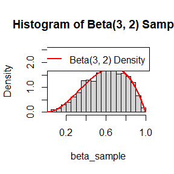

```r
# 定义生成Beta分布随机样本的函数
generate_beta_sample <- function(n, a, b) {
  # 定义接受-拒绝采样函数
  accept_reject <- function() {
    while (TRUE) {
      # 生成两个均匀分布随机数 U1 和 U2
      u1 <- runif(1)
      u2 <- runif(1)

      # 计算接受概率
    f_u1 <- dbeta(u1, a, b)  # Beta(a, b)的概率密度函数

    #这是密度函数的最大值
      g_u1 <- 12

      if (u2 <= f_u1 / g_u1) {
        return(u1)
      }
    }
  }

  # 生成随机样本
  beta_sample <- numeric(n)
  for (i in 1:n) {
    beta_sample[i] <- accept_reject()
  }

  return(beta_sample)
}

# 生成Beta(3, 2)分布的随机样本
sample_size <- 1000
a <- 3
b <- 2
beta_sample <- generate_beta_sample(sample_size, a, b)


hist(beta_sample, probability = TRUE, breaks = 30, ylim = c(0, 2.5), main = "Histogram of Beta(3, 2) Sample")

# 叠加理论Beta(3, 2)密度曲线
x <- seq(0, 1, length.out = 1000)
y <- dbeta(x, a, b)
lines(x, y, col = "red", lwd = 2)

# 添加图例
legend("topright", legend = "Beta(3, 2) Density", col = "red", lwd = 2)
```

## Question 4

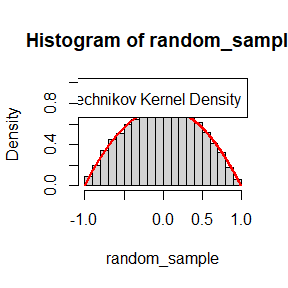

```r
# 定义生成随机变量样本的函数
generate_random_sample <- function(n) {
  random_sample <- numeric(n)

  for (i in 1:n) {
    # 生成Uniform(-1, 1)分布的三个随机数
    u1 <- runif(1, min = -1, max = 1)
    u2 <- runif(1, min = -1, max = 1)
    u3 <- runif(1, min = -1, max = 1)

    # 判断
    if (abs(u3) >= abs(u2) && abs(u3) >= abs(u1)) {
      random_sample[i] <- u2
    } else {
      random_sample[i] <- u3
    }
  }

  return(random_sample)
}

# 生成模拟随机样本
sample_size <- 10000
random_sample <- generate_random_sample(sample_size)

# 绘制直方图密度估计
hist(random_sample, probability = TRUE,ylim = c(0, 1), breaks = 15)

# 添加理论rescaled Epanechnikov核密度曲线
x <- seq(-1, 1, length.out = 1000)
epanechnikov_density <- (3/4) * (1 - x^2)
lines(x, epanechnikov_density, col = "red", lwd = 2)

# 添加图例
legend("topright", legend = "Rescaled Epanechnikov Kernel Density", col = "red", lwd = 2)
```

## Question 5

我们需要证明，这样基于生成[-1,1]随机分布的算法，最后得到的随机分布的密度函数是rescaled Epanechnikov核函数

# Homewok3

## Question 1

在Buffon’s niddle experiment中，对于圆周率$\pi$的估计来源于这样的等式:
$$P(\frac{1}{2}\sin Y \ge X)=\frac{2l}{d\pi}$$
其中各变量含义为：

- d：任意两条相邻线之间的距离
- l：针长（l≤d）
- Y：针和线之间的交叉角
- X：针中心到针的距离

当系数$\rho=\frac{l}{d}$取什么值的时候，$\hat{\pi}$的估计渐近方差是最小的？

## Answer 1

# Homework4

## Question 1

我们已经知道在计算一个区间上的积分$\int_a^b f(x)dx$时，分层抽样的方差如下:
$$\operatorname{Var}\left(\hat{\theta}^M\right)=\frac{1}{M
k} \sum_{i=1}^k
\sigma_i^2+\operatorname{Var}\left(\theta_I\right)=\operatorname{Var}\left(\hat{\theta}^S\right)+\operatorname{Var}\left(\theta_I\right)$$
, 其中$\theta_i=E[g(U) \mid I=i], \sigma_i^2=\operatorname{Var}[g(U) \mid I=i]$ ,$I$服从 $\{1, \ldots, k\}$上的均匀分布.

请证明在区间长度$|b_i-a_i| \rightarrow 0$时，$Var(\theta^S)/Var(\theta^M) \rightarrow 0$。

## Answer 1

因为
$$\frac{\sigma^2}{M}=\operatorname{Var}\left(\hat{\theta}^M\right)=\operatorname{Var}\left(\hat{\theta}^S\right)+\operatorname{Var}\left(\theta_I\right)=\frac{k}{M}
\sigma_j^2+Var(\theta_I)$$
由于$\theta_i=\int_{a_i}^{b_i} f(x) dx$，并且$f(x)$在闭区间$[a,b]$上有界，因此$f(x)$有界，那么当$|b_i-a_i| \rightarrow 0$时，对每个$i$而言，$\theta_i \rightarrow 0$，因此$Var(\theta_I)$趋于0，所以$Var(\theta^S)/Var(\theta^M) \rightarrow 0$

## Question 2

请找到在 区间$(1,+\infty)$作为支撑集的两个importance函数 f1 和 f2，使其“接近”于:
$$g(x)=\frac{x^2}{\sqrt{2\pi}}e^{-\frac{x^2}{2}}$$
并以此估计此函数在区间[1,+∞]上的积分，比较这两种估计的方差大小，最后做出解释。

## Answer 2

我们选取$f_1=(1-\Phi(1))^{-1}\frac{1}{\sqrt{2\pi}}e^{-\frac{x^2}{2}}$,$f_2(x)=e^{-(x-1)}$，$\hat{\theta}=\frac{1}{n}\sum(g(X_i)/f(X_i)$，根据此计算方法，我们求出$\hat{\theta}$方差为:
$$Var(\hat{\theta})=\int_1^\infty \frac{g^2(x)}{f(x)} dx-\theta^2$$

带入求出:

$$Var(\hat{\theta}_1)=(1-\Phi(1))\int_1^\infty
\frac{x^4}{\sqrt{2\pi}}e^{-\frac{x^2}{2}} dx$$

$$Var(\hat{\theta}_2)=\int_1^\infty\frac{x^4}{\sqrt{2\pi}}e^{-\frac{x^4}{2}+(x-1)}
dx$$
可知$Var(\hat{\theta_1})>Var(\hat{\theta_2})$。

## Question 5

假设应用 95% 对称 t 区间来估计平均值，但如果样本数据非正态。 那么置信区间的概率覆盖平均值不一定等于 0.95。使用蒙特卡罗实验估计随机样本的 t 区间的覆盖概率。 假设样本量 为n = 20 的 $\chi^2(2)$ 数据。

## Answer 5

```r
# 生成从卡方分布抽样的随机数
n=20
S<-0
M<-10000
alpha=0.05
for (i in 1:M)
  {

  chisq_sample <- rchisq(n, df = 2)
  t_alpha_over_1 <-mean(chisq_sample)+ qt(alpha / 2, df = n-1)*var(chisq_sample)/sqrt(n)
  t_alpha_over_2 <-mean(chisq_sample)+ qt(1 - alpha / 2, df = n-1)*var(chisq_sample)/sqrt(n)

  if(t_alpha_over_1<2 & t_alpha_over_2>2)
  {
    S<-S+1
  }

}
print(S/M)
## [1] 0.9472
```

这个结果表明均值$\mu$落在confidence interval的概率接近0.95，数值实验体现了t-interval的稳健性。

## Question 6

在蒙特卡罗模拟中，我们可以研究 t 检验的经验 I 类错误率，即在零假设为真的情况下拒绝零假设的概率 我们希望检验的是零假设 $H_0: \mu = \mu_0$，其中 $\mu_0$ 是分布为 $X$ 的总体均值，$X$ 分别是三种不同的分布：$\chi^2(1)$、Uniform(0, 2) 和指数分布($\text{Exponential}(1)$)。我们要检查经验 I 类错误率是否近似等于名义显著性水平 $\alpha$。

## Answer 6

以下是对这种情况的蒙特卡罗模拟的一般步骤：

```r
set.seed(123)

# 模拟参数
n_simulations <- 10000
sample_size <- 30
alpha <- 0.05


simulate_t_test <- function(distribution, mu0) {
  rejections <- 0

  for (i in 1:n_simulations) {

    if (distribution == "chi-square") {
      data <- rchisq(sample_size, df = 1)
    } else if (distribution == "uniform") {
      data <- runif(sample_size, min = 0, max = 2)
    } else if (distribution == "exponential") {
      data <- rexp(sample_size, rate = 1)
    }


    t_result <- t.test(data, mu = mu0)


    p_value <- t_result$p.value
    if (p_value < alpha) {
      rejections <- rejections + 1
    }
  }


  return(rejections / n_simulations)
}

# 三种不同分布的模拟试验
distribution_names <- c("chi-square", "uniform", "exponential")
mu0_values <- c(1, 1, 1)  # 对应三种分布的均值

for (i in 1:length(distribution_names)) {
  distribution_name <- distribution_names[i]
  mu0 <- mu0_values[i]

  error_rate <- simulate_t_test(distribution_name, mu0)

  cat(paste("Distribution:", distribution_name, "\n"))
  cat(paste("True Mean (mu0):", mu0, "\n"))
  cat(paste("Simulated Empirical Type I Error Rate:", error_rate, "\n\n"))
}
## Distribution: chi-square
## True Mean (mu0): 1
## Simulated Empirical Type I Error Rate: 0.0874
##
## Distribution: uniform
## True Mean (mu0): 1
## Simulated Empirical Type I Error Rate: 0.0541
##
## Distribution: exponential
## True Mean (mu0): 1
## Simulated Empirical Type I Error Rate: 0.0719
```

通过上述结果我们可以发现，当样本分布服从均匀分布时，type I error大小接近于显著性水平，当样本分布服从卡方分布或指数分布时，type I error会偏离显著性水平，因为这样的样本分布违反了理论假设。

# Homework 5

## Question 1

考虑$m=1000$个假设，前$95\%$对原假设成立，后$5\%$对对立假设成立，原假设下$p$值服从 U(0,1)分布，对立假设下服从$Beta(0.1,1)$分布，应用$Bonferroni$矫正和 $B-H$矫正于生成的m个p值，得到矫正后的p值，与$\alpha=0.1$比较确定是否拒绝原假设。 基于$M=1000$次模拟，估计FWER,FDR,TPR。

```r
alpha<-0.1
m<-1000

#初始化
count_Bf<-numeric(3)
count_BH<-numeric(3)

for (i in 1:m) {


p1<-runif(950,0,1)
p2<-rbeta(50,0.1,1)
p_vec<-c(p1,p2)

p_Bf<-p.adjust(p_vec,method ='bonferroni')
p_BH<-p.adjust(p_vec,method ='BH')

#计算FWER
if(min(p_Bf[1:950])<alpha)
{
  count_Bf[1]<-count_Bf[1]+1
}

if(min(p_BH[1:950])<alpha)
{
  count_BH[1]<-count_BH[1]+1
}


#计算FDR，先初始化错误率
error_rate_Bf<-0
error_rate_BH<-0


  error_rate_Bf<-sum(p_Bf[1:950]<alpha)/sum(p_Bf[1:1000]<alpha)
  error_rate_BH<-sum(p_BH[1:950]<alpha)/sum(p_BH[1:1000]<alpha)

  count_Bf[2]<-error_rate_Bf+count_Bf[2]
  count_BH[2]<-error_rate_BH+count_BH[2]



  #计算TPR


  count_Bf[3]<-sum(p_Bf[951:1000]<alpha)/50+count_Bf[3]
  count_BH[3]<-sum(p_BH[951:1000]<alpha)/50+count_BH[3]

  }

print("两种方法的FWER,FER,TPR依次为:")
## [1] "两种方法的FWER,FER,TPR依次为:"
print(count_Bf/m)
## [1] 0.072000000 0.003815318 0.393900000
print(count_BH/m)
## [1] 0.92600000 0.09204139 0.55878000
```

## Qusetion 2

利用bootstrap方法，估计指数分布的均值与方差，我们假设$\lambda=\frac{1}{\bar{X}}$，$\lambda=2$。对比bootstrap方法计算出的均值和方差与理论上的均值与方差。

## Answer 2

按照bootstrap的步骤，重复$M=1000$次。每个样本集做bootstrap次数为1000

```r
lambda <- 2
num_bootstrap_samples <- 1000
M<-1000


for (id in c(5,10,20)) {

sample_size <- id

# 生成原始指数分布的数据


# 定义函数执行Bootstrap抽样并计算统计量
bootstrap_mean <- function(data, num_samples)
{
  bootstrap_means <- numeric(num_samples)
  for (s in 1:num_samples) {
    resampled_data <- sample(data, replace = TRUE)
    bootstrap_means[s] <- 1/mean(resampled_data)
  }
  return(mean(bootstrap_means))
}

bootstrap_var <- function(data, num_samples) {
  bootstrap_means <- numeric(num_samples)
  for (s in 1:num_samples) {
    resampled_data <- sample(data, replace = TRUE)
bootstrap_means[s] <- 1/mean(resampled_data)
  }
  bootstrap_means<-bootstrap_means-lambda
  return(var(bootstrap_means))
}


# 执行Bootstrap抽样
bootstrap_bias<-numeric(M)
bootstrap_vars<-numeric(M)
for (i in 1:M) {

  original_data <- rexp(sample_size, rate = lambda)

bootstrap_bias[i] <- bootstrap_mean(original_data, num_bootstrap_samples)-lambda
bootstrap_vars[i] <- bootstrap_var(original_data, num_bootstrap_samples)

}
# 打印结果
cat("样本大小:",sample_size,"\n")
cat("Bootstrap bias:",mean(bootstrap_bias) , "bias真值", 2/(sample_size-1), "\n")
cat("Bootstrap方差:", mean(bootstrap_vars), "真实方差",lambda*sample_size/(sample_size*sqrt(sample_size-2)), "\n")

}
## 样本大小: 5
## Bootstrap bias: 1.06087 bias真值 0.5
## Bootstrap方差: 437.7952 真实方差 1.154701
## 样本大小: 10
## Bootstrap bias: 0.4065225 bias真值 0.2222222
## Bootstrap方差: 0.8563957 真实方差 0.7071068
## 样本大小: 20
## Bootstrap bias: 0.2067766 bias真值 0.1052632
## Bootstrap方差: 0.2824325 真实方差 0.4714045
```

## Qusetion 3

获取correlation统计量的 bootstrap t-置信区间估计,使用bootstrap包中的law 数据集。

```r
library("bootstrap")
law<-law82[c("LSAT","GPA")]
M<-1000
C<-numeric(M)
for(i in 1:M)
{
  sample_data<-sample(law,replace=TRUE)

  C[i]<- cor(sample_data[,1],sample_data[,2])
}

print(mean(C))
## [1] 0.8799989
cat("置信区间为:(",mean(C)-1.96*sd(C),",",mean(C)+1.96*sd(C),")")
## 置信区间为:( 0.6446791 , 1.115319 )
```

# Homework6

## Question 1

计算平均故障间隔时间 $1/\lambda$的 95% bootstrap 置信区间，分别利用 标准正态、basic、百分位、 和 BCa 方法。 比较置信区间并解释它们可能不同的原因。

## Answer 1

前三种方法直接按照置信区间的定义就可以求解$95\%$置信区间，针对BCa方法，我们需要调用例题中出现的BCa.boot()函数，以方便我们的计算:

```r
# 原始数据

data <- c(3,5,7,18,43,85,91,98,100,130,230,487)

# 设置Bootstrap参数
n <- length(data)
num_bootstrap_samples <- 1000
alpha <- 0.05  # 95% confidence interval

# 初始化变量来存储Bootstrap样本均值
bootstrap_sample_means <- numeric(num_bootstrap_samples)

# 执行Bootstrap抽样
for (i in 1:num_bootstrap_samples) {
  resampled_data <- sample(data, replace = TRUE)
  bootstrap_sample_means[i] <- mean(resampled_data)
}

# Standard Normal Method
se <- sd(bootstrap_sample_means)  # Standard error of sample means
z_alpha_over_2 <- qnorm(1 - alpha / 2)  # Z quantile

standard_normal_lower <- mean(bootstrap_sample_means) - z_alpha_over_2 * se
standard_normal_upper <- mean(bootstrap_sample_means) + z_alpha_over_2 * se



# Basic Bootstrap Method
bias <- mean(bootstrap_sample_means) - mean(data)
bias_corrected_mean <- mean(bootstrap_sample_means) - bias
basic_bootstrap_se <- sd(bootstrap_sample_means - bias)  # Bias-corrected SE

basic_lower <- bias_corrected_mean - qnorm(1 - alpha / 2) * basic_bootstrap_se
basic_upper <- bias_corrected_mean + qnorm(1 - alpha / 2) * basic_bootstrap_se

# Percentile Method
percentile_lower <- quantile(bootstrap_sample_means, alpha / 2)
percentile_upper <- quantile(bootstrap_sample_means, 1 - alpha / 2)



# BCa (Bias-Corrected and Accelerated) Method

library(boot)
theta.b <- numeric(num_bootstrap_samples)
  theta.hat <- mean(data)
  #bootstrap
  for (b in 1:num_bootstrap_samples) {
    i <- sample(1:n, size = n, replace = TRUE)
    theta.b[b] <- mean(data[i])
  }

  stat <- function(dat, index) {
    mean(dat[index]) }

  boot.BCa <-
    function(x, th0, th, stat, conf = .95) {

      x <- as.matrix(x)
      n <- nrow(x) #observations in rows
      N <- 1:n
      alpha <- (1 + c(-conf, conf))/2
      zalpha <- qnorm(alpha)
      # the bias correction factor
      z0 <- qnorm(sum(th < th0) / length(th))
      # the acceleration factor (jackknife est.)
      th.jack <- numeric(n)
      for (i in 1:n) {
        J <- N[1:(n-1)]
        th.jack[i] <- stat(x[-i, ], J)
      }
      L <- mean(th.jack) - th.jack
      a <- sum(L^3)/(6 * sum(L^2)^1.5)
      # BCa conf. limits
      adj.alpha <- pnorm(z0 + (z0+zalpha)/(1-a*(z0+zalpha)))
      limits <- quantile(th, adj.alpha, type=6)
      return(list("est"=th0, "BCa"=limits))
    }

  op<-boot.BCa(data, th0 = theta.hat, th = theta.b, stat = stat)

  bca_lower<-op$BCa[1]
  bca_upper<-op$BCa[2]

  cat("Standard Normal Method CI: [", standard_normal_lower, ", ", standard_normal_upper, "]\n")
## Standard Normal Method CI: [ 34.27047 ,  185.5615 ]


cat("Basic Bootstrap Method CI: [", basic_lower, ", ", basic_upper, "]\n")
## Basic Bootstrap Method CI: [ 32.4378 ,  183.7289 ]

cat("Percentile Method CI: [", percentile_lower, ", ", percentile_upper, "]\n")
## Percentile Method CI: [ 45.575 ,  194.1687 ]

cat("BCa Method CI: [", bca_lower, ", ", bca_upper, "]\n")
## BCa Method CI: [ 58.35666 ,  221.0252 ]
```

## Qusetion 2

利用jackknife算法,计算最大的特征值所占的比例$\theta=\frac{\lambda_1}{\sum_i^5 \lambda_i}$的bias和variance。其中$\lambda_i$的估计值来源于对$\Sigma$矩阵特征值的估计

## Answer 2

```r
 library(bootstrap)

data(scor)
data<-scor

cov_matrix <- cov(data)
eigen_result <- eigen(cov_matrix)


eigenvalues <- eigen_result$values


theta <- max(eigenvalues) / sum(eigenvalues)

# 创建一个函数
jackknife_estimate <- function(data) {
  n <- length(data)
  theta_estimates <- numeric(n)

  for (i in 1:n) {

    pseudo_data <- data[-i]

    pseudo_theta <- min(pseudo_data) / sum(pseudo_data)

    theta_estimates[i] <- pseudo_theta
  }


  bias <- (n - 1) * mean(theta_estimates) - theta


  se <- sqrt(((n - 1) / n) * sum((theta_estimates - mean(theta_estimates))^2))

  return(list(bias = bias, se = se))
}


jackknife_result <- jackknife_estimate(eigenvalues)

# 输出Jackknife估计的偏差和标准误差
cat("Jackknife Estimate of Bias:", jackknife_result$bias, "\n")
## Jackknife Estimate of Bias: -0.4164064
cat("Jackknife Estimate of Standard Error:", jackknife_result$se, "\n")
## Jackknife Estimate of Standard Error: 0.04360899
```

## Question 3

在示例 7.18 中，使用留一（n 重）交叉验证来选择 最佳拟合模型。 使用留二法交叉验证来比较模型

## Answer 3

按照例7.18的步骤，我们依次建立四类模型，在抽取数据的时候每轮循环排除两个数据点，其余步骤类似。

```r
library(DAAG)

calculate_prediction_error1 <- function(model, data) {
  predicted_values <- predict(model, newdata = data)
  actual_values <- data$magnetic
  error <- mean((predicted_values - actual_values)^2)
  return(error)
}

calculate_prediction_error2 <- function(model, data) {
  predicted_values <- predict(model, newdata = data)
  actual_values <- data$magnetic
  error <- mean((exp(predicted_values) - actual_values)^2)  # Mean Squared Error
  return(error)
}

data(ironslag)
data<-ironslag
# Define the proposed models
model_linear <- lm(magnetic ~ chemical, data = data)
model_quadratic <- lm(magnetic ~ chemical + I(chemical^2), data = data)
model_exponential <- lm(log(magnetic) ~ chemical, data = data)
model_log_log <- lm(log(magnetic) ~ log(chemical), data = data)

# Set the number
num_iterations <- nrow(data) * (nrow(data) - 1) / 2


errors_linear <- numeric(num_iterations)
errors_quadratic <- numeric(num_iterations)
errors_exponential <- numeric(num_iterations)
errors_log_log <- numeric(num_iterations)


set.seed(123)
iteration <- 1
for (i in 1:(nrow(data) - 1)) {
  for (j in (i + 1):nrow(data)) {
    validation_data <- data[c(i, j), ]
    training_data <- data[-c(i, j), ]

    # Calculate prediction errors for each model
    errors_linear[iteration] <- calculate_prediction_error1(model_linear, validation_data)
    errors_quadratic[iteration] <- calculate_prediction_error1(model_quadratic, validation_data)
    errors_exponential[iteration] <- calculate_prediction_error2(model_exponential, validation_data)
    errors_log_log[iteration] <- calculate_prediction_error2(model_log_log, validation_data)

    iteration <- iteration + 1
  }
}

# Calculate mean prediction errors for each model
mean_error_linear <- mean(errors_linear)
mean_error_quadratic <- mean(errors_quadratic)
mean_error_exponential <- mean(errors_exponential)
mean_error_log_log <- mean(errors_log_log)


cat("Mean Prediction Errors (Leave-Two-Out Cross-Validation):\n")
## Mean Prediction Errors (Leave-Two-Out Cross-Validation):
cat("Linear Model:", mean_error_linear, "\n")
## Linear Model: 18.02025
cat("Quadratic Model:", mean_error_quadratic, "\n")
## Quadratic Model: 15.84495
cat("Exponential Model:", mean_error_exponential, "\n")
## Exponential Model: 17.10349
cat("Log-Log Model:", mean_error_log_log, "\n")
## Log-Log Model: 18.9952
```

经过留2验证法比较MSE，我们可以得出最优模型应当是二次模型（ Quadratic Model ）。

#Homework 7

## Question 1

证明连续情况下，给定采样概率$\alpha(s, r)=\min \left\{\frac{f(r) g(s \mid r)}{f(s) g(r \mid s)}, 1\right\}$的马尔可夫链满足平稳性条件。

## Answer 1

在连续性条件下转移核为：
$$K(r, s)=\alpha(r, s) g(s \mid r)+I(s=r)\left[1-\int \alpha(r, s) g(s
\mid r)\right] \text {. }$$
由于$f(s),g(s)$均是连续性随机变量的密度函数。因此示性函数$I(s=r)=1$的概率测度为0.所以$K(s,r)=\alpha(r,s)g(s|r)$

那么我们只需验证 $K(s, r) f(s)=K(r, s) f(r)$这一等式成立即可。这与离散情形下的证明一致，带入计算即可。

## Qusstion 2

实施等分布的双样本 Cramer-von Mises 检验 。 利用例 8.1 和 8.2 中的数据。

## Answer 2

在这里我们首先使用了 twosamples 包，它包含了执行两样本统计检验的函数。先使用 cvm_test 函数计算 x 和 y 的Cramér-von Mises统计量，存储在 cv_statistic_observed 变量中。

下一步通过迭代循环，进行了 num_permutations 次置换。 在每次迭代中，代码首先随机排列合并后的数据，然后将它们分割为两个与原始样本相同大小的样本，使用 cvm_test 函数计算Cramér-von Mises统计量，并将结果存储在 cv_statistics_permuted 中。最后比较出p值。

```r
library(twosamples)
attach(chickwts)
x <- sort(as.vector(weight[feed == "soybean"]))
y <- sort(as.vector(weight[feed == "linseed"]))
detach(chickwts)


cv_statistic_observed <- cvm_test(x,y)[1]


pooled_data <- c( x, y)

num_permutations <- 1000

cv_statistics_permuted <- numeric(num_permutations)


set.seed(123)
for (i in 1:num_permutations) {
  permuted_data <- sample(pooled_data, replace = FALSE)

  # Split the permuted data into two samples
  permuted_sample1 <- permuted_data[1:length(x)]
  permuted_sample2 <- permuted_data[(length(x) + 1):length(permuted_data)]

  # Calculate the Cramér-von Mises statistic for the permuted samples
  cv_statistics_permuted[i] <- cvm_test(permuted_sample1, permuted_sample2)[1]
}


p_value <- sum(cv_statistics_permuted >= cv_statistic_observed) / num_permutations

# Display the results
cat("原样本的 Cramér-von Mises 统计量:", cv_statistic_observed, "\n")
## 原样本的 Cramér-von Mises 统计量: 0.6096939
cat("Permutation Test p-value:", p_value, "\n")
## Permutation Test p-value: 0.44
```

据此可知我们接受原假设.

## Question 3

第 6.4 节中的等方差”count 5 test”基于 极值点的数量。 例 6.15 表明计数 5 准则 不适用于不相等的样本量。 请开发一个permutation test 适用于最大极值点数量的等方差检验 当样本量不一定相等时

## Answer 3

在permutation Test的步骤中： 1. 计算观察到的检验统计量 $\hat{\theta}(X, Y)=\hat{\theta}(Z, \nu)$。 2. 对于每个重复，索引 $b=1, \ldots, B$ ： (a) 生成随机排列 $\pi_b=\pi(\nu)$。 (b) 计算统计量 $\hat{\theta}^{(b)}=\hat{\theta}^*\left(Z, \pi_b\right)$。 3. 如果 $\hat{\theta}$ 的较大值支持备择假设，则通过以下方式计算 经验 $p$ 值
$$\hat{p}=\frac{1+\#\left\{\hat{\theta}^{(b)} \geq
\hat{\theta}\right\}}{B+1}=\frac {\left\{1+\sum_{b=1}^B
I\left(\hat{\theta}^{(b)} \geq \hat{\theta}\right)\right\}}{B+ 1}$$

在这个问题中，我们将估计量取为$\theta(X,Y)=\{\text{number of extreme point}\}$

我们借用section6.5里面的max out函数，用于计算x,y两个样本的极值点个数。

```r
maxout <- function(x, y) {
  X <- x - mean(x)
  Y <- y - mean(y)
  outx <- sum(X > max(Y)) + sum(X < min(Y))
  outy <- sum(Y > max(X)) + sum(Y < min(X))
  return(max(c(outx, outy)))
}


n1 <- 20
n2 <- 50
mu1 <- mu2 <- 0
sigma1 <-1
sigma2 <-1
m <- 1000

p_list <- numeric(100)
for (j in 1:100)
{


x <- rnorm(n1, mu1, sigma1)
y <- rnorm(n2, mu2, sigma2)
cv_statistic_observed<-maxout(x,y)



pooled_data <- c(x, y)

num_permutations <- 1000

cv_statistics_permuted <- numeric(num_permutations)


for (i in 1:num_permutations) {
  permuted_data <- sample(pooled_data, replace = FALSE)

  # Split the permuted data into two samples
  permuted_sample1 <- permuted_data[1:length(x)]
  permuted_sample2 <- permuted_data[(length(x) + 1):length(permuted_data)]

  # Calculate the Cramér-von Mises statistic for the permuted samples
  cv_statistics_permuted[i] <- maxout(permuted_sample1,permuted_sample2)
}

p_list[j]=sum(cv_statistics_permuted > cv_statistic_observed) / num_permutations
}
mean(p_list)
## [1] 0.44076

cat("原样本的 Cramér-von Mises 统计量:", cv_statistic_observed, "\n")
## 原样本的 Cramér-von Mises 统计量: 8
cat("Permutation Test p-value:", p_value, "\n")
## Permutation Test p-value: 0.44
```

在第一个实验里，我们令原假设成立，$n1=20,n2 = 50,sigma1 =1,sigma2 =1$

# Homework 8

## Question 1

1. 考虑一个模型 $P\left(Y=1 \mid X_1, X_2, X_3\right)=\frac{\exp \left(a+b_1 X_1+b_2 X_2+b_3 X_3\right)}{1+\ exp \left(a+b_1 X_1+b_2 X_2+b_3 X_3\right)}$，其中 $X_1 \sim P(1)、X_2 \sim \operatorname{Exp}(1)$ 和 $X_3 \sim B(1 ,0.5)$。
- 设计一个函数，将 $N、b_1、b_2、b_3$ 和 $f_0$ 作为输入值，并生成输出 $a$。
- 调用此函数，输入值为$N=10^6, b_1=0, b_2=1, b_3=-1, f_0=0.1,0.01,0.001,0.0001$。
- 绘制 $-\log f_0$ 与 $a$ 的对比图。

## Qusetion 2

实现随机游走 Metropolis 采样器来生成标准拉普拉斯分布。 比较不同方差建议分布生成的链 。 另外，计算每条链的接受率

## Answer2

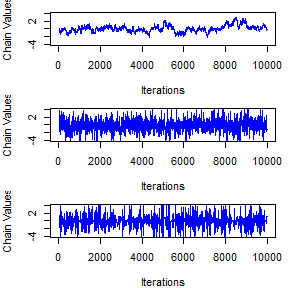

```
## Proposal SD: 10  Acceptance Rate: 0.1504
```

```r
laplace_pdf <- function(x) {
  return(0.5 * exp(-abs(x)))
}


metropolis_sampler <- function(iterations, proposal_sd) {

  chain <- numeric(iterations)
  acceptance_count <- 0
  current_value <- rnorm(1)


  for (i in 1:iterations) {

    proposal_value <- current_value + rnorm(1, mean = 0, sd = proposal_sd)


    acceptance_ratio <- min(1, laplace_pdf(proposal_value) / laplace_pdf(current_value))

    if (runif(1) < acceptance_ratio) {
      current_value <- proposal_value
      acceptance_count <- acceptance_count + 1
    }

    chain[i] <- current_value
  }

  # 计算接受率
  acceptance_rate <- acceptance_count / iterations

  return(list(chain = chain, acceptance_rate = acceptance_rate))
}


iterations <- 10000
proposal_sd_values <- c(0.1, 1, 10)



par(mfrow = c(3, 1), mar = c(4, 4, 1, 1))


for (proposal_sd in proposal_sd_values) {

  result <- metropolis_sampler(iterations, proposal_sd)


  plot(result$chain, type = "l", col = "blue", xlab = "Iterations", ylab = "Chain Values",
       main = "", ylim = c(-4, 4))


  cat("Proposal SD:", proposal_sd, "\tAcceptance Rate:", result$acceptance_rate, "\n")
}
## Proposal SD: 0.1     Acceptance Rate: 0.9576
## Proposal SD: 1   Acceptance Rate: 0.6994
```

在上述代码中，我们比较了三种不同的方差建议分布（0.1、1、10）。较小的方差导致样本接受率较高，但可能会有较长的收敛时间。较大的方差可能导致更快的移动，但接受率可能较低，浪费计算资源。因此在实际操作中，需要对建议分布的方差做取舍。

## Qusetion 3

使用吉布斯采样器来生成二元正态链（Xt，Yt） ，$X,Y$的均值为零、标准差为1，相关性为 0.9。 绘制 丢弃合适的启动样本后生成的样本。 适合简单的 对样本建立线性回归模型 Y = β0 + β1X 并检查残差 正态性和常数方差的模型。

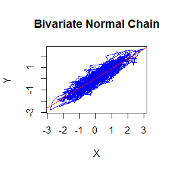

```r
gibbs_sampler <- function(n, rho = 0.9) {

  x <- numeric(n)
  y <- numeric(n)


  x[1] <- rnorm(1)
  y[1] <- rnorm(1)


  for (t in 2:n) {

    x[t] <- rnorm(1, mean = rho * y[t - 1], sd = sqrt(1 - rho^2))


    y[t] <- rnorm(1, mean = rho * x[t], sd = sqrt(1 - rho^2))
  }

  # Return the bivariate normal chain
  return(data.frame(X = x, Y = y))
}


set.seed(123)


n <- 1000
chain <- gibbs_sampler(n, rho = 0.9)

plot(chain$X, chain$Y, type = "l", col = "blue", xlab = "X", ylab = "Y", main = "Bivariate Normal Chain")



lm_model <- lm(Y ~ X, data = chain)
abline(lm_model, col = "red")
```

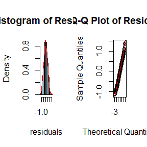

```r
residuals <- residuals(lm_model)


par(mfrow = c(1, 2))
hist(residuals, main = "Histogram of Residuals", col = "lightblue", probability = TRUE)
lines(density(residuals), col = "red")


qqnorm(residuals, main = "Q-Q Plot of Residuals")
qqline(residuals, col = "red")
```

```r
cat("Intercept:", coef(lm_model)[1], "\n")
```

```
## Intercept: 0.013328
```

```r
cat("beta:", coef(lm_model)[2], "\n")
```

```
## beta: 0.8657498
```

在“Bivariate Normal Chain”图中，我们观察到了采样出的$(X,Y)$散点图近似分布呈一个椭圆形，这与相关系数$\rho=0.9$的二元正态分布的密度函数类似，表明我们采样的结果良好。第二张图表明回归模型拟合良好，并且误差服从正态性分布，回归系数$\beta$约等于0.9，也验证了题目所给的相关系数0.9的条件。

## Question 4

请参阅示例 9.1。 使用 Gelman-Rubin 方法监控收敛性 链，并运行该链，直到该链大约收敛到$ R^2 <1.2$ 的目标分布。也可以使用coda 包，用于Gelman-Rubin 方法检查链的收敛性。

## Answer 4

在代码中，我们定义了metropolis_hastings_rayleigh函数实现了Metropolis-Hastings算法。它接受两个参数：n表示采样的数量，sigma_proposal表示建议分布的标准差。并且我们使用了coda包中的gelman.diag函数计算各个参数的Gelman-Rubin收敛诊断，使用gelman.plot函数生成Gelman-Rubin诊断图。

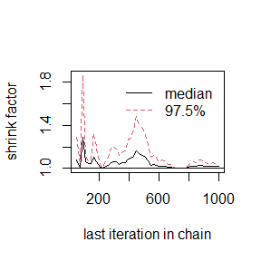

```r
library(coda)

f_computed<-function(x,sigma1)
{
  return(  (x)/sigma1^2 *exp(1)^{-x^2/(2*sigma1^2)} )
}

metropolis_hastings_rayleigh <- function(n, sigma_proposal)
  {
  x <- numeric(n)
  x[1] <- 1

  for (t in 2:n) {
    x_proposed <- x[t - 1] + rnorm(1, 0, sigma_proposal)

    acceptance_ratio <- min(1, f_computed(x_proposed,1)/f_computed(x[t - 1],1)  )

    if (runif(1) < acceptance_ratio)
  {
      x[t] <- x_proposed
    } else {
      x[t] <- x[t - 1]
    }
  }

  return(x)
}

set.seed(123)

n_samples <- 1000
sigma_proposal <- 0.5
chain <- metropolis_hastings_rayleigh(n_samples, sigma_proposal)

num_chains <- 3

chains <- lapply(1:num_chains, function(i) metropolis_hastings_rayleigh(n_samples, sigma_proposal))

mcmc_chains <- lapply(chains, as.mcmc)

mcmc_list <- mcmc.list(mcmc_chains)

gelman_diag <- gelman.diag(mcmc_list)

print(gelman_diag)
## Potential scale reduction factors:
##
##      Point est. Upper C.I.
## [1,]       1.02       1.04

gelman.plot(mcmc_list)
```

结果显示当sanple次数逐渐增大500以上时，$R^2$会降到1.2以下，这表明我们构造的马尔可夫链最终是收敛的。

# Homework 9

## Question 1

设$X_1,...,X_n$服从参数为$\lambda$的指数分布，因为某种原因，只知道$X_i$存在于区间$[u_i,v_i]$，这两个数是已知常数，这种数据称为区间删失数据。

(1)请你分别采用EM算法和最大化似然函数求解$\lambda$的MLE，并且证明EM算法在这种数据下是收敛的，并且是收敛速度是线性的.

(2)假设10个观测值数据为: $(11,12),(8,9),(27,28),(13,14),(16,17),(0,1),(23,24),(10,11),(24,25),(2,3)$，计算结果

## Answer 1

1. 首先，我们考虑区间删失数据下的最大似然估计（MLE）问题。

假设观测到的数据为$X_1, X_2, \ldots, X_n$，其中$X_i$的真实取值存在于区间$[u_i, v_i]$。指数分布的概率密度函数为$f(x;\lambda) = \lambda e^{-\lambda x}$，其中$\lambda$是指数分布的参数。对于区间删失数据，我们需要计算观测数据的似然函数。

似然函数为：

$$L(\lambda) = \prod_{i=1}^{n} P(u_i \leq
X_i \leq v_i;\lambda)$$

由于$X_i$在区间$[u_i, v_i]$之间服从均匀分布，其概率为：

$$P(u_i \leq X_i \leq v_i;\lambda) =
\int_{u_i}^{v_i} \lambda e^{-\lambda x} \,dx = \lambda e^{-\lambda u_i}
- \lambda e^{-\lambda v_i}$$

取对数似然函数为：

$$\log L(\lambda) = \sum_{i=1}^{n} \log
(\lambda e^{-\lambda u_i} - \lambda e^{-\lambda v_i})$$

最大化对数似然函数即求解以下方程：

$$\frac{\partial \log
L(\lambda)}{\partial \lambda} = 0$$

接下来，我们考虑采用EM算法求解$\lambda$的估计值。EM算法的迭代步骤如下：

1. **E步骤（Expectation Step）**：计算给定当前参数$\lambda$下观测数据的期望（隐变量的条件概率分布）。
2. **M步骤（Maximization Step）**：最大化在E步骤中计算的期望，得到新的参数$\lambda$。

对于指数分布，我们假设这其中的隐变量是$X_i$具体的值，参数是$\lambda$。

初始化$\lambda_0=1$， - E步:计算隐变量$X_i$的期望，具体来说，$X_i$服从区间$[u_i,v_i]$上截断的指数分布。

- M步：用$X_1,...,X_n$作为样本，直接用极大似然方法估计$\lambda$。

由于EM算法的收敛性是已知结论，这是因为每一步迭代过程中对数似然都是单调递增的，收敛性易证。关于收敛速度：

EM算法的全局收敛速度定义为
$$\rho=\lim _{t \rightarrow \infty}
\frac{\left\|\theta^{(t+1)}-\hat{\theta}\right\|}{\left\|\theta^{(t)}-\hat{\theta}\right\|}$$
$\mathrm{EM}$ 算法定义了一个映射 $\theta^{(t+1)}=\Psi\left(\theta^{(t)}\right)$, 其中 $\theta=\left(\theta_1, \ldots, \theta_p\right), \Psi(\theta)=$ $\left(\Psi\left(\theta_1\right), \ldots, \Psi\left(\theta_p\right)\right)$, 当 EM算法收玫时, 如果收敛到该映射的一个不动点, 那 么 $\hat{\theta}=\Psi(\hat{\theta})$. 设 $\Psi^{\prime}(\theta)$ 表示其Jacobi矩阵, 其 $(i, j)$ 元素为 $\frac{\partial \Psi_i(\theta)}{\partial \theta_j}$. 则有
$$\theta^{(t+1)}-\hat{\theta} \approx
\Psi^{\prime}\left(\theta^{(t)}\right)\left(\theta^{(t)}-\hat{\theta}\right)$$

因此当 $p=1$ 时, $\mathrm{EM}$ 算法有线性收敛。若对 $p>1$, 若fisher信息阵 $-l^{\prime \prime}(\hat{\theta} \mid x)$ 是正定的, 则 收敛仍是线性的。

```r
# 观测数据
data <- matrix(c(11, 12, 8, 9, 27, 28, 13, 14, 16, 17, 0, 1, 23, 24, 10, 11, 24, 25, 2, 3), ncol = 2, byrow = TRUE)

# EM算法
lambda <- 1

for (iter in 1:100) {
  # E步
  E_values <- numeric(nrow(data))
   for (i in 1:nrow(data)) {
    integrand <- function(x) {
      x * lambda * exp(-lambda * x) / (exp(-lambda *data[i, 1])-exp(-lambda *data[i, 2]))
    }

    E_values[i] <- integrate(integrand, lower = data[i, 1], upper = data[i, 2])$value
  }



  lambda_new <- 1 / mean(E_values)


  if (abs(lambda_new - lambda) < 1e-6) {
    break
  } else {
    lambda <- lambda_new
  }
}


print(paste("最大似然估计：", 1 / mean(data)))
## [1] "最大似然估计： 0.0719424460431655"


print(paste("EM算法估计：", lambda))
## [1] "EM算法估计： 0.0719736704199017"
```

## Question 2

在 Morra 博弈中，如果常数为常数，则最优策略集不会改变 从支付矩阵的每个条目中减去一个正常数乘以支付矩阵的每个条目。 然而，单纯形 算法可能会在不同的基本可行点（也是最优的）处终止。计算 B <- A + 2，找到游戏 B 的解，并验证它是否原始游戏 A 的极值点 (11.12)–(11.15)。同时找到 游戏A和游戏B的价值

## Answer 2

```r
library(boot)


solve.game <- function(A) {
#solve the two player zero-sum game by simplex method
#optimize for player 1, then player 2
#maximize v subject to ...
#let x strategies 1:m, and put v as extra variable
#A1, the <= constraints
#
min.A <- min(A)
A <- A - min.A #so that v >= 0
max.A <- max(A)
A <- A / max(A)
m <- nrow(A)
n <- ncol(A)
it <- n^3
a <- c(rep(0, m), 1) #objective function
A1 <- -cbind(t(A), rep(-1, n)) #constraints <=
b1 <- rep(0, n)
A3 <- t(as.matrix(c(rep(1, m), 0))) #constraints sum(x)=1
b3 <- 1
sx <- simplex(a=a, A1=A1, b1=b1, A3=A3, b3=b3,
maxi=TRUE, n.iter=it)
#the ’solution’ is [x1,x2,...,xm | value of game]
#
#minimize v subject to ...
#let y strategies 1:n, with v as extra variable
a <- c(rep(0, n), 1) #objective function
A1 <- cbind(A, rep(-1, m)) #constraints <=
b1 <- rep(0, m)
A3 <- t(as.matrix(c(rep(1, n), 0))) #constraints sum(y)=1
b3 <- 1
sy <- simplex(a=a, A1=A1, b1=b1, A3=A3, b3=b3,
maxi=FALSE, n.iter=it)
soln <- list("A" = A * max.A + min.A,
"x" = sx$soln[1:m],
"y" = sy$soln[1:n],
"v" = sx$soln[m+1] * max.A + min.A)
soln
}


A <- matrix(c( 0,-2,-2,3,0,0,4,0,0,
2,0,0,0,-3,-3,4,0,0,
2,0,0,3,0,0,0,-4,-4,
-3,0,-3,0,4,0,0,5,0,
0,3,0,-4,0,-4,0,5,0,
0,3,0,0,4,0,-5,0,-5,
-4,-4,0,0,0,5,0,0,6,
0,0,4,-5,-5,0,0,0,6,
0,0,4,0,0,5,-6,-6,0), 9, 9)

s <- solve.game(A+2)

round(cbind(s$x, s$y), 7)
```

```
##         [,1]      [,2]
## x1 0.0000000 0.0000000
## x2 0.0000000 0.0000000
## x3 0.4098361 0.4098361
## x4 0.0000000 0.0000000
## x5 0.3278689 0.3278689
## x6 0.0000000 0.0000000
## x7 0.2622951 0.2622951
## x8 0.0000000 0.0000000
## x9 0.0000000 0.0000000
```

正如题所说，在给pay-off矩阵加减上常数后，不影响结果，并且极值点也不变。极值点仍为 $(0, 0, 5/12, 0, 4/12, 0, 3/12, 0, 0)$, $(0, 0, 16/37, 0, 12/37, 0, 9/37, 0, 0)$, $(0, 0, 20/47, 0, 15/47, 0, 12/47, 0, 0)$, $(0, 0, 25/61, 0, 20/61, 0, 16/61, 0, 0)$.

# Homework 10

## Question 1

在R语言中，为什么需要使用unlist()将列表转换为原子 向量？ 为什么 as.vector() 不起作用？

## Answer 1

在R语言中，unlist()函数和as.vector()函数都可以用于将列表（list）转换为原子向量（atomic vector）。但是，它们的行为有所不同。

unlist()函数用于将列表的所有元素递归展开成一个原子向量。如果列表中有嵌套的子列表，unlist()会将其递归展开为一个平铺的原子向量。这意味着，如果列表结构比较复杂，unlist()可以将其一维化。

而as.vector()函数的行为取决于输入的对象。如果输入的对象是一个原子向量，它会返回相同的原子向量。但是，如果输入的对象是一个列表，as.vector()并不会递归展开列表，而是返回一个仍然是列表的原子向量，并不会展开原子列表。

## Question 2

应用于向量时，dim() 返回什么？

## Answer 2

在 R 中，dim() 函数用于获取或设置数组、矩阵或数据框的维度。 当应用于可被视为一维数组的向量时，dim() 返回 NULL。

这是一个例子:

```r
my_vector <- c(1, 2, 3, 4, 5)

dimensions <- dim(my_vector)

print(dimensions)
```

[output not shown]

## Question 3

如果 is.matrix(x) 为 TRUE，is.array(x) 将返回什么？

## Answer 3

在R语言中，is.array(x) 也将返回TRUE。因为在R中矩阵是数组的一种特殊类型，其维度为2。

## Qusetion 4

当将 as.matrix() 应用于数据框时，它会做什么针对不同类型的列？

## Answer 4

as.matrix() 会尽量将数据框的列转换为统一的类型，通常是数值型或字符型。并且按照这样的变量等级取这些变量类型中的最高级：
$$logical < integer < double < character < list$$
例如：

```r
my_df <- data.frame(a = c(1, 2, 3), b = c("apple", "banana", "orange"))

my_matrix <- as.matrix(my_df)

str(my_matrix)
```

```
##  chr [1:3, 1:2] "1" "2" "3" "apple" "banana" "orange"
##  - attr(*, "dimnames")=List of 2
##   ..$ : NULL
##   ..$ : chr [1:2] "a" "b"
```

## Question 5

你可以有一个 0 行的数据框吗？ 0列呢？

## Answer 5

是可以的。

```r
# 创建一个0行的数据框
empty_df_rows <- data.frame()

# 打印结果
print(empty_df_rows)
```

```
## data frame with 0 columns and 0 rows
```

```r
# 创建一个0列的数据框
empty_df_cols <- data.frame(matrix(nrow = 1, ncol = 0))

# 打印结果
print(empty_df_cols)
```

```
## data frame with 0 columns and 1 row
```

## Question 6

## Answer 6

如果只是想对每个列使用scale函数，用apply函数即可。如果想将 scale01 函数仅应用于数据框中的数值型列变量，可以使用 dplyr 包的 mutate_if 函数：

```r
scale01 <- function(x) {
  rng <- range(x, na.rm = TRUE)
  (x - rng[1]) / (rng[2] - rng[1])
}


my_df <- data.frame(
  A = c(1, 2, 3),
  B = c(4, 5, 6),
  C = c(7, 8, 9)
)

# 使用 apply 函数应用 scale01 到每一列
scaled_df <- apply(my_df, 2, scale01)


print(scaled_df)
```

```
##        A   B   C
## [1,] 0.0 0.0 0.0
## [2,] 0.5 0.5 0.5
## [3,] 1.0 1.0 1.0
```

```r
library(dplyr)
my_df <- data.frame(
  A = c(1, 2, 3),
  B = c(4, 5, 6),
  C = c(7, 8, 9),
  D = c("apple", "banana", "orange"),
  E = c(TRUE, FALSE, TRUE)
)


scaled_df <- my_df %>%
  mutate_if(is.numeric, scale01)


print(scaled_df)
```

```
##     A   B   C      D     E
## 1 0.0 0.0 0.0  apple  TRUE
## 2 0.5 0.5 0.5 banana FALSE
## 3 1.0 1.0 1.0 orange  TRUE
```

## Question 7

使用 vapply() 完成： a) 计算数值数据框中每列的标准差。 b) 计算每个数字列的标准差 在混合数据框中。

## Answer 7

```r
numeric_df <- data.frame(
  A = c(1, 2, 3),
  B = c(4, 5, 6),
  C = c(7, 8, 9)
)

std_devs <- vapply(numeric_df, sd, numeric(1))

print(std_devs)
```

```
## A B C
## 1 1 1
```

```r
mixed_df <- data.frame(
  A = c(1, 2, 3),
  B = c(4, 5, 6),
  C = c(7, 8, 9),
  D = c("apple", "banana", "orange"),
  E = c(TRUE, FALSE, TRUE)
)


numeric_std_devs <- vapply(mixed_df, function(x) if(is.numeric(x)) sd(x) else NA, numeric(1))


print(numeric_std_devs)
```

```
##  A  B  C  D  E
##  1  1  1 NA NA
```

## Question 8

考虑练习 9.8

• 编写一个R 函数。 • 编写Rcpp 函数。 • 将两个函数的计算时间与函数“microbenchmark”进行比较

其中，练习9.8的题目是： 考虑双变量密度
$$f(x, y) = y^{x+a-1}(1-y)^{n-x+b-1}, \quad x=0,1, \ldots, n, 0 \leq y
\leq 1 。$$

对于固定的 $a, b, n$，条件分布为 $\operatorname{Binomial}(n, y)$ 和 $\operatorname{Beta}(x+a, n-x+b)$。 使用吉布斯采样器生成目标联合密度 $f(x, y)$ 的链。

## Answer 8

```r
# 安装并加载 microbenchmark 包
# install.packages("microbenchmark")
library(microbenchmark)

# 定义R函数
gibbs_sampler_R <- function(n, a, b, iterations) {
  x <- numeric(iterations)
  y <- numeric(iterations)

  for (i in 1:iterations) {
    # 从条件分布中采样
    if(i==1)
    {
      s<-0
    }
    else{
      s<-x[i-1]
    }
    y[i] <- rbeta(1, s + a, n - s + b)
    x[i] <- rbinom(1, n, y[i])
  }

  return(data.frame(x, y))
}

# 运行 microbenchmark 比较计算时间
result_R <- microbenchmark(gibbs_sampler_R(10, 2, 3, 1000))
print(result_R)
```

```
## Unit: milliseconds
##                             expr      min       lq     mean   median       uq
##  gibbs_sampler_R(10, 2, 3, 1000) 2.935401 3.092251 4.439917 3.347151 4.940351
##      max neval
##  11.5988   100
```

```r
library(Rcpp)
sourceCpp(code='
#include <Rcpp.h>
using namespace Rcpp;


// [[Rcpp::export]]
NumericMatrix gibbs_sampler_Rcpp(int n, double a, double b, int iterations)
{
  NumericVector x(iterations);
  NumericVector y(iterations);
  NumericMatrix out_stat(iterations,2);
  double s;

  for (int i = 0; i < iterations; i++) {
    if(i==0)
    {
      s=0;
    }
    else
    {
      s=x(i-1);
    }

    y(i) = R::rbeta(s + a, n - s + b);
    x(i) = R::rbinom( n, y(i));
    out_stat(i,0) = x(i);
    out_stat(i,1) = y(i);
  }

  return out_stat;
}
')

# 运行 microbenchmark 比较计算时间
result_Rcpp <- microbenchmark::microbenchmark(gibbs_sampler_Rcpp(10, 2, 3, 1000))
print(result_Rcpp)
```

```
## Unit: microseconds
##                                expr     min       lq    mean   median       uq
##  gibbs_sampler_Rcpp(10, 2, 3, 1000) 239.201 249.1015 288.876 256.6505 274.9515
##       max neval
##  2247.401   100
```